# Data Exploration and Dynamics

This vignette presents two analyses of growth-related attributes: the Frequency Report summarizes sample distributions across spatial locations, while the Spatial–Temporal Report visualizes interpolated attributes over space and time.

### Frequency

The Frequency Report provides frequency distributions across locations, summarizing patterns at the site, tree, and sample levels, and highlighting data completeness, variability, and potential gaps for further analysis.

```r
# loading processed data
# otherwise need to run CFS_format() first as done in data report
 dt.samples_trt <- readRDS(system.file("extdata", "dt.samples_trt.rds", package = "growthTrendR"))
 # Compute frequency statistics at radius level
 dt.freq <- CFS_freq(
   data = dt.samples_trt$tr_all_wide,
   freq.label_data = "demo-samples",
   freq.uid_level  = "uid_radius"
 )
```

##### **arguments of CFS_freq() function:**

**data**

Metadata table generated by the function CFS_format().

**freq.label_data**

A short description of the dataset used. This text will appear in the report as the data source for the generated figures.

**freq.uid_level**

Specifies the hierarchical level at which frequencies are counted (e.g., site, tree, sample, or radius).

#### **generate report:**

```r
generate_report(robj = dt.freq)
```

##### **arguments of the generate_report() function:**

**robj**

The input for the frequency report is the output of the CFS_freq() function, which assigns the class “cfs_freq” to the resulting object.

**output_file**

The output_file argument allows users to generate an HTML report at a specified path and file name. If set to NULL (default), the report opens automatically in the browser.

## Frequency report

2026-05-30

This report presents an analysis of the distribution of samples across geographical locations, stratified by species, providing insights into sampling coverage and spatial patterns.

source data: **demo-samples**

uid level: **uid_radius**

cuttoff year: **-999**

Spatial resolution: **1** degree (longitude); **1** (latitude)

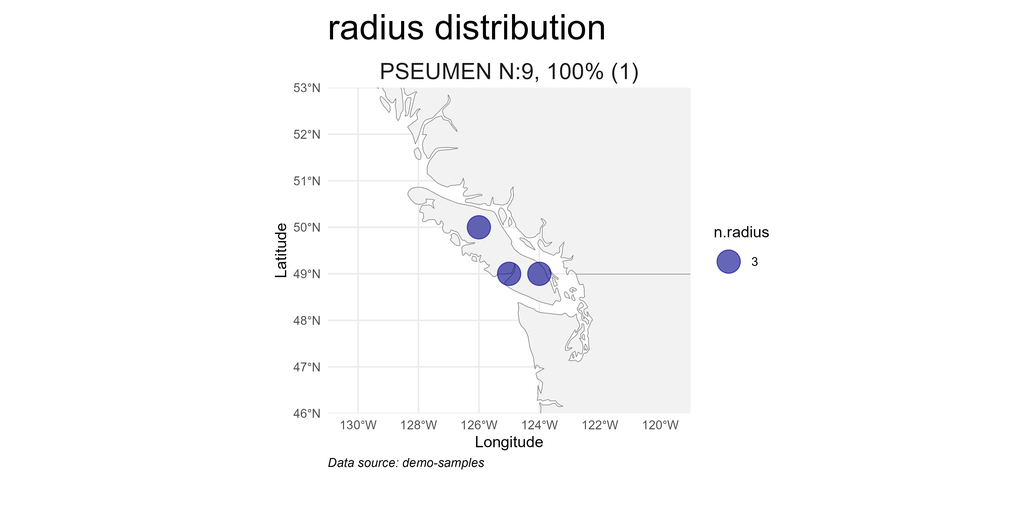

### Spatial-Temporal report

This report presents the spatial–temporal dynamics of growth-related attributes (e.g., ring width, basal area increment, chronology indices, or model-predicted values). The variables are interpolated across the study region using the CFS_mapping() function with the inverse distance weighting (IDW) method, and the resulting raster layers are compiled into a GIF for visualization.

```r
# loading processed data
dt.samples_trt <- readRDS(system.file("extdata", "dt.samples_trt.rds", package = "growthTrendR"))


# data processing

cols.meta = c("uid_tree", "uid_site", "longitude", "latitude", "species")

dt.mapping <- dt.samples_trt$tr_all_wide[
  , c(..cols.meta, as.character(1991:1995)), with = FALSE]

results_mapping <- CFS_mapping(data = dt.mapping, year.span = c(1991,1995))
```

##### **arguments of CFS_mapping() function:**

**data**

The input dataset must include at least five columns: uid_tree, uid_site, longitude, latitude, and species, followed by annual attribute columns labeled by year (e.g., 1991, 1992, …).

### **generate report:**

```r
# e.g. series to check
generate_report(robj = results_mapping,
                png.text = list(
                  text_top  = "Ring width measurment - ",
                  text_bott = "Source: demo-samples",
                  text_side = "ring width (mm)"
                )
                )
```

##### **arguments of the generate_report() function:**

**robj**

The input for the spatial-temporal report is the output of the CFS_mapping() function, which assigns the class “cfs_mapping” to the resulting object.

**png.text**

A list of text labels for the plot. Supported elements are text_top, text_bott, and text_side.

## Spatio-Temporal Dynamics Report

2026-05-30

The following animation illustrates temporal patterns of a key attribute across a geographic region. Values at discrete locations are interpolated using the inverse distance weighting (IDW) method to create continuous yearly surfaces. The animation provides a dynamic view of spatio-temporal trends, highlighting patterns and potential anomalies in the data.

#### all.spp

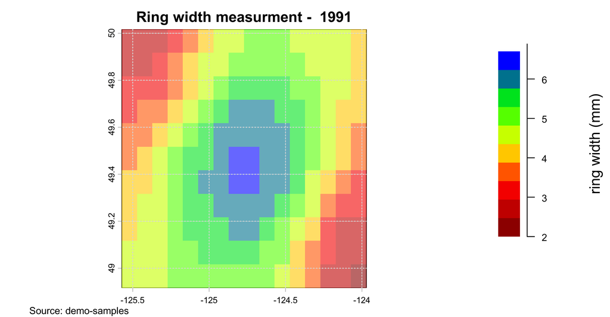